# DS400: Assignment 05 (R)

Jiazhen Li (Student ID: 6295370)

2023-01-26

```r
library(jsonlite)
library(httr)
library(rlist)
library(tidyverse)

rm(list = ls())
setwd(
  "C:/Users/Zhenzhen/Desktop/University/M.Sc. Tübingen/2022-2023 WS/Data Science Project Management/Assignments/Assignment_5"
)
```

### Setting up a new GitHub repository

1. Register on github.com in case you have not done this already.
2. Initialize a new public repository for this assignment on GitHub.
3. For the following exercises of this assignment, follow the standard Git workflow (i.e., pull the latest version of the project to your local computer, then stage, commit, and push all the modifications that you make throughout the project). Every logical programming step should be well documented on GitHub with a meaningful commit message, so that other people (e.g., your course instructor) can follow and understand the development history. You can do this either using Shell commands or a Git GUI of your choice.
4. In the HTML file that you submit, include the hyperlink to the project repository

#### My repository: https://github.com/jzhenli1/Assignment_5.git

### Getting to know the API

5. Visit the documentation website for the API provided by ticketmaster.com. Familiarize yourself with the features and functionalities of the Ticketmaster Discovery API. Have a particular look at rate limits.
6. Whithin the scope of this assignment, you do not have to request your own API key. Instead retrieve a valid key from the API Explorer. This API key enables you to perform the GET requests needed throughout this assignment. Even though this API key is not secret per se (it is publicly visible on the API Explorer website), please comply to the common secrecy practices discussed in the lecture and the tutorial: Treat the API key as a secret token. Your API key should neither appear in the code that you are submitting nor in your public GitHub repository.

All API keys are issued with a default quota of 5000 API calls per day and rate limitation of 5 requests per second.

```r
source("Ticketmaster_API_Key.R")  # API Key in separate R file (.gitignore R files)
```

### Interacting with the API - the basics

7. Perform a first `GET` request, that searches for event venues in Germany (`countryCode = "DE"`). Extract the `content` from the `response` object and inspect the resulting list. Describe what you can see.

```r
APIcontent <- GET("https://app.ticketmaster.com/discovery/v2/venues/",  # only package version v2 gives results
                  query = list(apikey = ticketmaster_key,
                               "countryCode" = "DE",
                               "locale" = "*")) %>% content()
#APIcontent
```

The content list contains an embedded list of venues, each venue with its own sublist. Each venue list contains several elements (e.g., name, type, url, timezone etc.). Some of these elements stand alone (such as `name` “Grosse Freiheit 36”), while other elements are themselves another list (such as `country` which contains both the `name` “Germany” and the `countrycode` “DE”). At the end of the content list, there is a summary of `totalElements` and `totalPages` which indicates that the request has a total of 12932 elements (aka venues) distributed over 647 pages on the website.

8. Extract the `name`, the `city`, the `postalCode` and `address`, as well as the `url` and the `longitude` and `latitude` of the venues to a data frame.

```r
# Extracting name
ref <- APIcontent[["_embedded"]][["venues"]]
Name <- map_chr(ref, ~.[["name"]])

# Extracting city
City <- map_chr(ref, ~.[["city"]][["name"]])

# Extracting postal code
PostalCode <- map(ref, ~.[["postalCode"]])

nullToNA <- function(x) {         # create function to change NULL to NA
    x[sapply(x, is.null)] <- NA
    return(x)
}

PostalCode <- nullToNA(PostalCode) %>% unlist()

#Extracting address
Address <- map(ref , ~.[["address"]][["line1"]])
Address <- nullToNA(Address) %>% unlist()

# Extracting url
URL <- map_chr(ref, ~.[["url"]])

# Extracting longitude
Longitude <- map(ref, ~.[["location"]][["longitude"]])
Longitude <- nullToNA(Longitude) %>% unlist()

# Extracting latitude
Latitude <- map(ref, ~.[["location"]][["latitude"]])
Latitude <- nullToNA(Latitude) %>% unlist()

# Putting into dataframe
venues <- data.frame(Name, City, PostalCode, Address, URL, Longitude, Latitude)
```

### Interacting with the API - advanced

9. Have a closer look at the list element named page. Did your `GET` request from exercise (7) return all event locations in Germany? Obviously not - there are of course much more venues in Germany than those contained in this list. Your `GET` request only yielded the first results page containing the first 20 out of several thousands of venues. Check the API documentation under the section Venue Search. How can you request the venues from the remaining results pages? Iterate over the results pages and perform `GET` requests for all venues in Germany. After each iteration, extract the seven variables `name`, `city`, `postalCode`, `address`, `url`, `longitude`, and `latitude`. Join the information in one large data frame. Print the first 10 rows and the shape of the resulting data frame.

```r
# Creating a function for easier reproducibility of the process
venues_df <- function(countrycode){
  APIcontent <- GET("https://app.ticketmaster.com/discovery/v2/venues/",
                    query = list(apikey = ticketmaster_key,
                                 "countryCode" = countrycode,
                                 "locale" = "*")) %>% content()
  # Determining number of pages
  pages <- as.numeric(APIcontent[["page"]][["totalPages"]])

  # Creating empty lists to be appended
  NameAll <- c()
  CityAll <- c()
  PostalCodeAll <- c()
  AddressAll <- c()
  URLAll <- c()
  LongitudeAll <- c()
  LatitudeAll <- c()

  # for loop for all pages
  for (i in 0:(pages - 1)) {

    # To prevent exceeding rate limit
    Sys.sleep(.2)

    refAll <- NULL

    # Preventing "Error in x[sapply(x, is.null)] <- NA : invalid subscript type 'list'"
    while (is.null(refAll)) {
      allVenues <- GET("https://app.ticketmaster.com/discovery/v2/venues/",
                       query = list(apikey = ticketmaster_key,
                                    "countryCode" = countrycode,
                                    "locale" = "*",
                                    "page" = i))

      allVenues_content <- content(allVenues)
      refAll <- allVenues_content[["_embedded"]][["venues"]]
      }

    Name <- map(refAll, ~.[["name"]])
    Name <- nullToNA(Name) %>% unlist()
    City <- map(refAll, ~.[["city"]][["name"]])
    City <- nullToNA(City) %>% unlist()
    PostalCode <- map(refAll, ~.[["postalCode"]])
    PostalCode <- nullToNA(PostalCode) %>% unlist()
    Address <- map(refAll , ~.[["address"]][["line1"]])
    Address <- nullToNA(Address) %>% unlist()
    URL <- map(refAll, ~.[["url"]])
    URL <- nullToNA(URL) %>% unlist()
    Longitude <- map(refAll, ~.[["location"]][["longitude"]])
    Longitude <- nullToNA(Longitude) %>% unlist()
    Latitude <- map(refAll, ~.[["location"]][["latitude"]])
    Latitude <- nullToNA(Latitude) %>% unlist()

    NameAll <- append(NameAll, Name)
    CityAll <- append(CityAll, City)
    PostalCodeAll <- append(PostalCodeAll, PostalCode)
    AddressAll <- append(AddressAll, Address)
    URLAll <- append(URLAll, URL)
    LongitudeAll <- append(LongitudeAll, Longitude)
    LatitudeAll <- append(LatitudeAll, Latitude)
    }

  # Combine into dataframe
  df <- data.frame(NameAll, CityAll, PostalCodeAll, AddressAll,
                          URLAll, LongitudeAll, LatitudeAll)

  return(df)
}

# Call the function
venues_DE <- venues_df("DE")

# Change variables from character to double
venues_DE$PostalCodeAll <- as.double(venues_DE$PostalCodeAll)
venues_DE$LongitudeAll <- as.double(venues_DE$LongitudeAll)
venues_DE$LatitudeAll <- as.double(venues_DE$LatitudeAll)


dim(venues_DE)
```

```
## [1] 12934     7
```

```r
print(head(venues_DE, 10))
```

```
##                     NameAll      CityAll PostalCodeAll            AddressAll
## 1        Grosse Freiheit 36      Hamburg         22767    Grosse Freiheit 36
## 2                 Gruenspan      Hamburg         22767    Grosse Freiheit 58
## 3         Huxleys Neue Welt       Berlin         10967  Hasenheide 107 – 113
## 4           Zentrum am Park Emmelshausen         56281 Rhein-Mosel-Straße 45
## 5  Stadthalle (Theatersaal)      Mülheim         45479 Theodor-Heuss-Platz 1
## 6             Schlossgarten     Bruchsal         76646      Schloss Bruchsal
## 7                Stadthalle   Hockenheim         68766       Rathausstraße 3
## 8                       FZW     Dortmund         44263       Ritterstraße 20
## 9               Arena Trier        Trier         54292    Fort-Worth-Platz 1
## 10            Eissporthalle    Memmingen         87700   Hühnerbergstraße 19
##                                                                                      URLAll
## 1                                                   http://www.ticketmaster.de/venue/287636
## 2                                                   http://www.ticketmaster.de/venue/287155
## 3                                                   http://www.ticketmaster.de/venue/286842
```

[output cut: 18 more lines]

### Visualizing the extracted data

10. Add points to the map indicating the locations of the event venues across Germany.

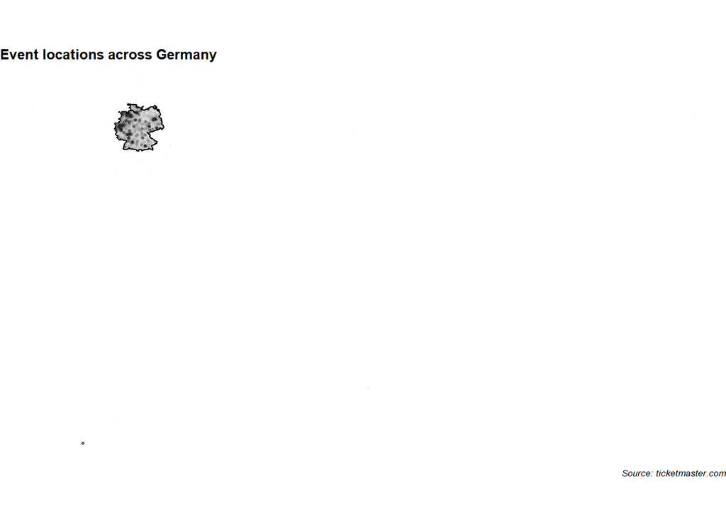

```r
ggplot(venues_DE) +
  borders("world", "Germany", colour = "black", fill = "grey90") +

  # Adding coordinates of locations
  geom_point(aes(LongitudeAll, LatitudeAll), alpha = 1/100, size = 0.5) +
  # alpha (transparency) makes venue overlap more visible

  theme_void() +
  coord_quickmap() +
  labs(title = "Event locations across Germany",
  caption = "Source: ticketmaster.com") +
  theme(title = element_text(size = 8, face = 'bold'),
  plot.caption = element_text(face = "italic"))
```

11. You will find that some coordinates lie way beyond the German borders and can be assumed to be faulty. Set coordinate values to NA where the value of `longitude` is outside the range (`5.866`, `15.042`) or where the value of latitude is outside the range (`47.270`, `55.059`)

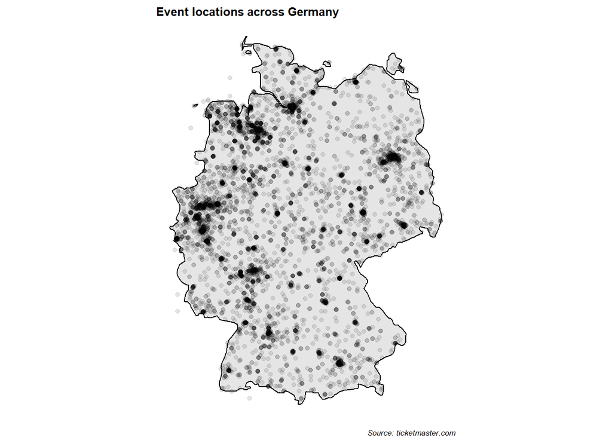

```r
venues_DE$LongitudeAll[venues_DE$LongitudeAll < 5.866 | venues_DE$LongitudeAll > 15.042] <- NA
venues_DE$LatitudeAll[venues_DE$LatitudeAll < 47.270 | venues_DE$LatitudeAll > 55.059] <- NA

ggplot(venues_DE) +
  borders("world", "Germany", colour = "black", fill = "grey90") +
  geom_point(aes(LongitudeAll, LatitudeAll), alpha = 1/10) +
  theme_void() +
  coord_quickmap() +
  labs(title = "Event locations across Germany",
  caption = "Source: ticketmaster.com") +
  theme(title = element_text(size = 8, face = 'bold'),
  plot.caption = element_text(face = "italic"))
```

### Event locations in other countries

12. Repeat exercises (9)–(11) for another European country of your choice.

```r
# Country: Switzerland, code: "CH"
venues_CH <- venues_df("CH")

venues_CH$PostalCodeAll <- as.double(venues_CH$PostalCodeAll)
venues_CH$LongitudeAll <- as.double(venues_CH$LongitudeAll)
venues_CH$LatitudeAll <- as.double(venues_CH$LatitudeAll)

dim(venues_CH)
```

```
## [1] 425   7
```

```r
print(head(venues_CH, 10))
```

```
##                   NameAll             CityAll PostalCodeAll
## 1     Salle de l'Alhambra              Genève          1204
## 2  Kulturfabrik KUFA Lyss                Lyss          3250
## 3       Klostersaal Stans               Stans          6370
## 4      ILFISHALLE Langnau Langnau im Emmental          3550
## 5      Stadion Letzigrund              Zürich          8048
## 6          St Jakobshalle               Basel          4052
## 7                   Moods              Zürich          8005
## 8               AXA ARENA          Winterthur          8400
## 9        Konzertfabrik Z7            Pratteln          4133
## 10                  Plaza              Zürich          8004
##                 AddressAll
## 1  Rue de la Rôtisserie 10
## 2          Werdtstrasse 17
## 3           Mürgstrasse 18
```

[output cut: 29 more lines]

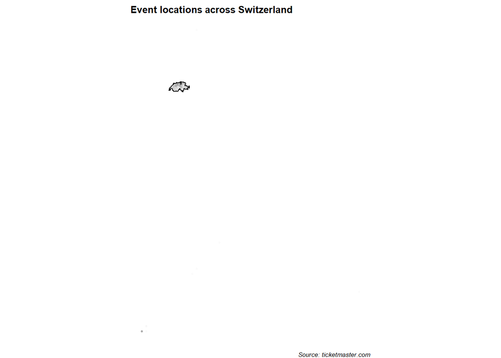

```r
# Preliminary visualization
ggplot(venues_CH) +
  borders("world", "Switzerland", colour = "black", fill = "grey90") +
  geom_point(aes(LongitudeAll, LatitudeAll), alpha = 1/100, size = 0.5) +
  theme_void() +
  coord_quickmap() +
  labs(title = "Event locations across Switzerland",
  caption = "Source: ticketmaster.com") +
  theme(title = element_text(size = 8, face = 'bold'),
  plot.caption = element_text(face = "italic"))
```

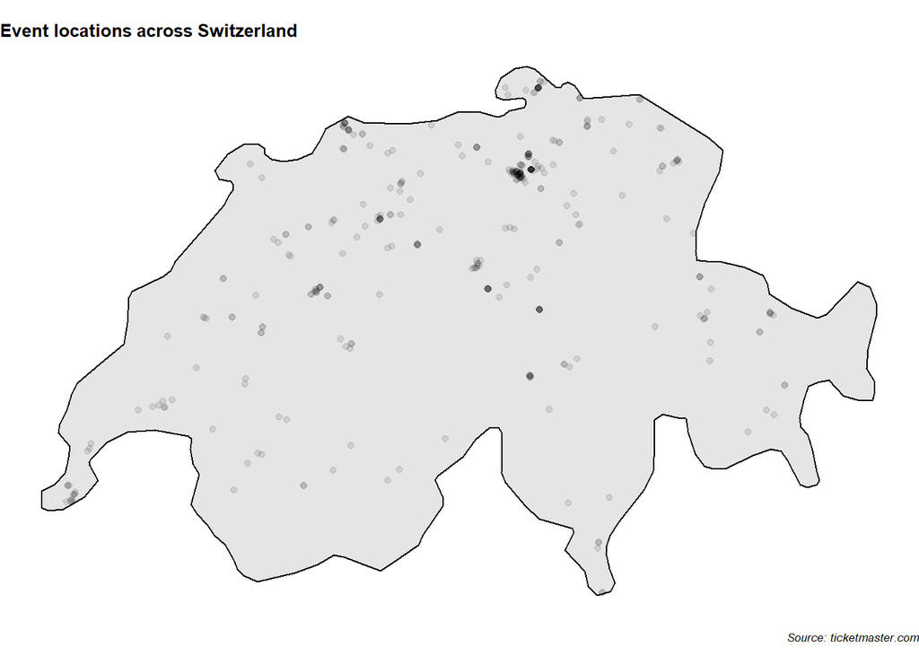

```r
# Visualization with coordinate restrictions
venues_CH$LongitudeAll[venues_CH$LongitudeAll < 5.956 | venues_CH$LongitudeAll > 10.492] <- NA
venues_CH$LatitudeAll[venues_CH$LatitudeAll < 45.818 | venues_CH$LatitudeAll > 47.808] <- NA

ggplot(venues_CH) +
  borders("world", "Switzerland", colour = "black", fill = "grey90") +
  geom_point(aes(LongitudeAll, LatitudeAll), alpha = 1/10) +
  theme_void() +
  coord_quickmap() +
  labs(title = "Event locations across Switzerland",
  caption = "Source: ticketmaster.com") +
  theme(title = element_text(size = 8, face = 'bold'),
  plot.caption = element_text(face = "italic"))
```